# Análise Exploratória de Dados

# Pergunta Aberta

**Exercício 01**

- Lembrar de carregar em “outline” ao lado direito

Uma imagem:

[figure not shown]

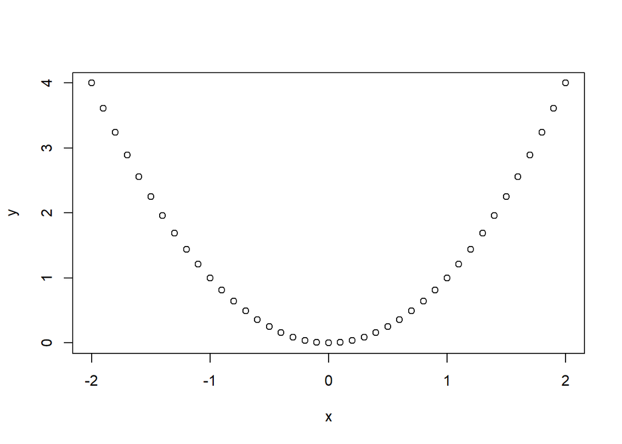

```r
x = seq(-2,2,0.1)
y = x^2
plot(x,y)
```

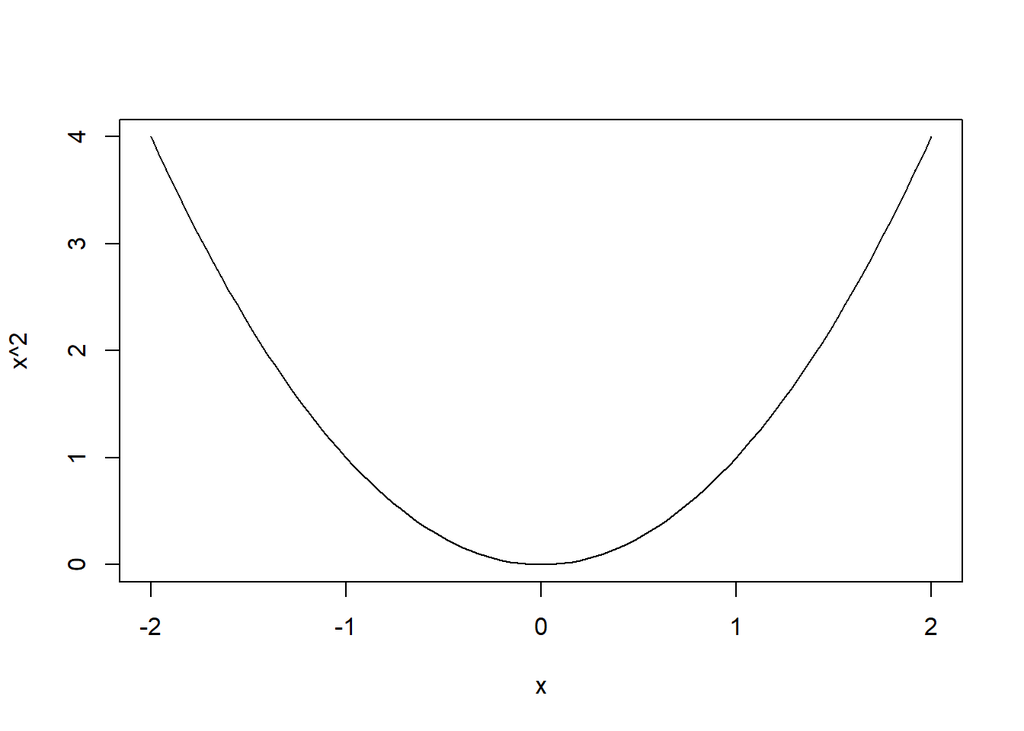

```r
curve(x^2, from = -2, to = 2)
```

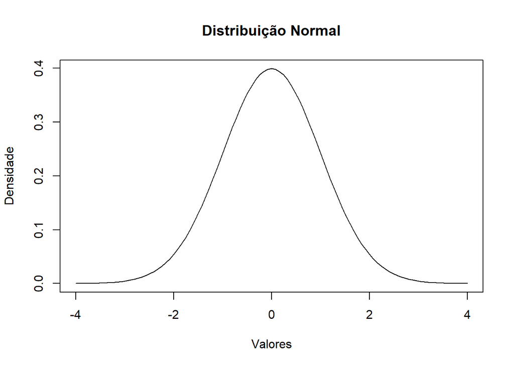

```r
# Define a média e o desvio padrão
media <- 0
desvio_padrao <- 1

# Cria o gráfico da distribuição normal
curve(dnorm(x, mean = media, sd = desvio_padrao), from = -4, to = 4,
      xlab = "Valores", ylab = "Densidade",
      main = "Distribuição Normal")
```

**Alínea (a)**

Palavras-chave

Proposta de resolução

**Alínea (b)**

Palavras-chave

Proposta de resolução

**Alínea (c)**

No ISCED/Cabinda a disciplina de Estatística, as avaliações são divididas em três categorias: **Prova**, **Trabalho Prático** e **Participação em Sala de Aula**, com pesos respectivos de **5**, **3** e **2**. Um estudante obteve as seguintes notas:Prova:**12,5**; Trabalho Prático: **12**; Participação em Sala de Aula : **9,5** . Calcule a média do estudante nessa disciplina” .

Palavras-chave

Proposta de resolução

**Exercício 02**

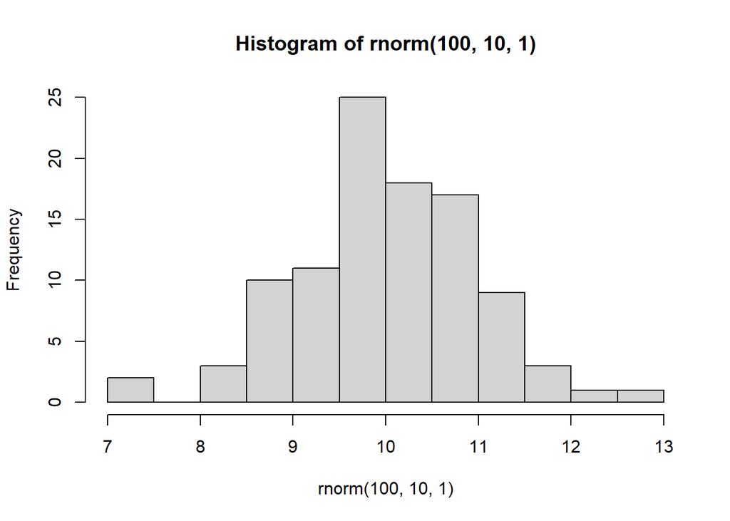

```r
set.seed(90) #produz sempre os mesmos dados
hist(rnorm(100,10,1))
```

**Alínea (a)**

Palavras-chave

Proposta de resolução

**Alínea (b)**

Palavras-chave

Proposta de resolução